# Backtests

Abstract

“Backtests” published in R News.

## Introduction

The **backtest** package provides facilities for exploring portfolio-based conjectures about financial instruments (stocks, bonds, swaps, options, et cetera). For example, consider a claim that stocks for which analysts are raising their earnings estimates perform better than stocks for which analysts are lowering estimates. We want to examine if, on average, stocks with raised estimates have higher future returns than stocks with lowered estimates and whether this is true over various time horizons and across different categories of stocks. Colloquially, “backtest” is the term used in finance for such tests.

## Background

To demonstrate the capabilities of the **backtest** package we will consider a series of examples based on a single real-world data set. StarMine[^1] is a San Francisco research company which creates quantitative equity models for stock selection. According to the company:

StarMine Indicator is a 1-100 percentile ranking of stocks that is predictive of future analyst revisions. StarMine Indicator improves upon basic earnings revisions models by:

- Explicitly considering management guidance.
- Incorporating SmartEstimates, StarMine’s superior estimates constructed by putting more weight on the most accurate analysts.
- Using a longer-term (forward 12-month) forecast horizon (in addition to the current quarter).

StarMine Indicator is positively correlated to future stock price movements. Top-decile stocks have annually outperformed bottom-decile stocks by 27 percentage points over the past ten years across all global regions.

These ranks and other attributes of stocks are in the `starmine` data frame, available as part of the **backtest** package.

```
> data("starmine")
> names(starmine)

[1] "date"      "id"        "name"
[4] "country"   "sector"    "cap.usd"
[7] "size"      "smi"       "fwd.ret.1m"
[10] "fwd.ret.6m"
```

`starmine` contains selected attributes such as sector, market capitalisation, country, and various measures of return for a universe of approximately 6,000 securities. The data is on a monthly frequency from January, 1995 through November, 1995. The number of observations varies over time from a low of 4,528 in February to a high of 5,194 in November.

| date | count |
| --- | --- |
| 1995-01-31 | 4593 |
| 1995-02-28 | 4528 |
| 1995-03-31 | 4569 |
| 1995-04-30 | 4708 |
| 1995-05-31 | 4724 |
| 1995-06-30 | 4748 |
| 1995-07-31 | 4878 |
| 1995-08-31 | 5092 |
| 1995-09-30 | 5185 |
| 1995-10-31 | 5109 |
| 1995-11-30 | 5194 |

The `smi` column contains the StarMine Indicator score for each security and date if available. Here is a sample of rows and columns from the data frame:

| date | name | fwd.ret.1m | fwd.ret.6m | smi |
| --- | --- | --- | --- | --- |
| 1995-01-31 | Lojack Corp | 0.09 | 0.8 | 96 |
| 1995-02-28 | Raymond Corp | 0.05 | 0.1 | 85 |
| 1995-02-28 | Lojack Corp | 0.08 | 0.7 | 90 |
| 1995-03-31 | Lojack Corp | 0.15 | 1.0 | 49 |
| 1995-08-31 | Supercuts Inc | -0.11 | -0.5 | 57 |
| 1995-10-31 | Lojack Corp | -0.40 | -0.2 | 22 |
| 1995-11-30 | Lojack Corp | 0.20 | 0.4 | 51 |

Most securities (like LoJack above) have multiple entries in the data frame, each for a different date. The row for Supercuts indicates that, as of the close of business on August 31, 1995, its `smi` was 57. During the month of September, its return (i.e., `fwd.ret.1m`) was -11%.

## A simple backtest

Backtests are run by calling the function `backtest` to produce an object of class `backtest`.

```
> bt <- backtest(starmine, in.var = "smi",
+   ret.var = "fwd.ret.1m")
```

`starmine` is a data frame containing all the information necessary to conduct the backtest. `in.var` and `ret.var` identify the columns containing the input and return variables, respectively. `backtest` splits observations into 5 (the default) quantiles, or “buckets,” based on the value of `in.var`. Lower (higher) buckets contain smaller (larger) values of `in.var`. Each quantile contains an approximately equal number of observations. This backtest creates quantiles according to values in the `smi` column of `starmine`.

[output not shown]

`backtest` calculates the average return within each bucket. From these averages we calculate the spread, or the difference between the average return of the highest and lowest buckets.

Calling `summary` on the resulting object of class `backtest` reports the `in.var`, `ret.var`, and `by.var` used. We will use a `by.var` in later backtests.

```
> summary(bt)
```

Backtest conducted with:

```
1 in.var: smi;
1 ret.var: fwd.ret.1m;
and no by.var.
```

|  | low | 2 | 3 | 4 | high | spread |
| --- | --- | --- | --- | --- | --- | --- |
| pooled | 0.011 | 0.013 | 0.016 | 0.02 | 0.032 | 0.021 |

This backtest is an example of a *pooled* backtest. In such a backtest, we assume that all observations are exchangeable. This means that a quantile may contain observations for any stock and from any date. Quantiles may contain multiple observations for the same stock.

The backtest summary shows that the average return for the highest bucket was 3.2%. This value is the mean one month forward return of stocks with `smi` values in the highest quantile. As the observations are exchangeable, we use every observation in the `starmine` data frame with a non-missing `smi` value. This means that the returns for LoJack from both 1995-01-31 and 1995-02-28 would contribute to the 3.2% mean of the high bucket.

The backtest suggests that StarMine’s model predicted performance reasonably well. On average, stocks in the highest quantile returned 3.2% while stocks in the lowest quantile returned 1.1%. The spread of 2.1% suggests that stocks with high ratings perform better than stocks with low ratings.

## Natural backtests

A *natural* backtest requires that the frequency of returns and observations be the same.

A natural backtest approximates the following implementation methodology: in the first period form an equal weighted portfolio with long positions in the stocks in the highest quantile and short positions in the stocks in the lowest quantile. Each stock has an equal weight in the portfolio; if there are 5 stocks on the long side, each stock has a weight of 20%. Subsequently rebalance the portfolio every time the `in.var` values change. If the observations have a monthly frequency, the `in.var` values change monthly and the portfolio must be rebalanced accordingly. When the `in.var` values change, rebalancing has the effect of exiting positions that have left the top and bottom quantiles and entering positions that have entered the top and bottom quantiles. If the data contains monthly observations, we will form 12 portfolios per year.

To create a simple natural backtest, we again call `backtest` using `fwd.ret.1m`. This is the only return value in `starmine` for which we can construct a natural backtest of `smi`.

```
> bt <- backtest(starmine, id.var = "id",
+   date.var = "date", in.var = "smi",
+   ret.var = "fwd.ret.1m", natural = TRUE)
```

Natural backtests require a `date.var` and `id.var`, the names of the columns in the data frame containing the dates of the observations and unique security identifiers, respectively. Calling `summary` displays the results of the backtest:

```
> summary(bt)
```

Backtest conducted with:

```
1 in.var: smi;
1 ret.var: fwd.ret.1m;
and no by.var.
```

|  | low | 2 | 3 | 4 | high | spread |
| --- | --- | --- | --- | --- | --- | --- |
| 1995-01-31 | 0.003 | 0.011 | 0.003 | -0.0001 | 0.019 | 0.016 |
| 1995-02-28 | -0.008 | -0.003 | 0.003 | 0.0072 | 0.013 | 0.021 |
| 1995-03-31 | 0.029 | 0.017 | 0.013 | 0.0225 | 0.037 | 0.008 |
| 1995-04-30 | -0.002 | -0.003 | 0.002 | -0.0054 | 0.005 | 0.007 |
| 1995-05-31 | 0.010 | 0.013 | 0.019 | 0.0228 | 0.044 | 0.034 |
| 1995-06-30 | 0.072 | 0.059 | 0.057 | 0.0708 | 0.101 | 0.030 |
| 1995-07-31 | 0.033 | 0.030 | 0.034 | 0.0323 | 0.052 | 0.018 |
| 1995-08-31 | -0.004 | 0.006 | 0.017 | 0.0119 | 0.024 | 0.028 |
| 1995-09-30 | -0.055 | -0.030 | -0.031 | -0.0219 | -0.014 | 0.041 |
| 1995-10-31 | 0.030 | 0.032 | 0.040 | 0.0430 | 0.038 | 0.008 |
| 1995-11-30 | 0.013 | 0.016 | 0.021 | 0.0294 | 0.037 | 0.024 |
| MEAN | 0.011 | 0.014 | 0.016 | 0.0193 | 0.032 | 0.021 |

```
average turnover: 0.5
mean spread: 0.02
sd spread: 0.01
raw sharpe ratio: 2
```

Focus on the mean return of the highest quantile for 1995-02-28 of 1.3%. `backtest` calculated this value by first computing the 5 quantiles of the input variable `smi` over all observations in `starmine`. Among the observations that fall into the highest quantile, those with date 1995-02-28 contribute to the mean return of 1.3%. It is important to note that the input variable quantiles are computed over the whole dataset, as opposed to within each category that may be defined by a `date.var` or `by.var`.

Calling `summary` yields information beyond that offered by the `summary` method of a pooled backtest. The first piece of extra information is average turnover. Turnover is the percentage of the portfolio we would have to change each month if we implemented the backtest as a trading strategy. For example, covering all the shorts and shorting new stocks would yield a turnover of 50% because we changed half the portfolio. We trade stocks when they enter or exit the extreme quantiles due to `in.var` changes. On average, we would turn over 50% of this portfolio each month.

The second piece of extra information is mean spread. The spread was positive each month, so on average the stocks with the highest `smi` values outperformed the stocks with the lowest `smi` values.

On average, stocks in the highest quantile outperformed stocks in the lowest quantile by 2%. The third piece of extra information, the standard deviation of spread, is 1%. The spread varied from month to month, ranging from a low of close to 0% to a high of over 4%.

We define the fourth piece of extra information, raw (non-annualized) Sharpe ratio, as $\frac{\text{return}}{\text{risk}}$. We set return equal to mean spread return and use the standard deviation of spread return as a measure of risk.

### More than one `in.var`

`backtest` allows for more than one `in.var` to be tested simultaneously. Besides using `smi`, we will test market capitalisation in dollars, `cap.usd`. This is largely a nonsense variable since we do not expect large cap stocks to outperform small cap stocks — if anything, the reverse is true historically.

```
> bt <- backtest(starmine, id.var = "id",
+   date.var = "date", in.var = c("smi",
+     "cap.usd"), ret.var = "fwd.ret.1m",
+   natural = TRUE)
```

Because more than one `in.var` was specified, only the spread returns for each `in.var` are displayed, along with the summary statistics for each variable.

```
> summary(bt)
```

Backtest conducted with:

```
2 in.vars: smi, cap.usd;
1 ret.var: fwd.ret.1m;
and no by.var.
```

|  | smi | cap.usd |
| --- | --- | --- |
| 1995-01-31 | 0.016 | -0.0138 |
| 1995-02-28 | 0.021 | 0.0017 |
| 1995-03-31 | 0.008 | -0.0023 |
| 1995-04-30 | 0.007 | -0.0052 |
| 1995-05-31 | 0.034 | -0.0568 |
| 1995-06-30 | 0.030 | -0.0143 |
| 1995-07-31 | 0.018 | -0.0008 |
| 1995-08-31 | 0.028 | 0.0051 |
| 1995-09-30 | 0.041 | 0.0321 |
| 1995-10-31 | 0.008 | 0.0127 |
| 1995-11-30 | 0.024 | 0.0029 |

```
summary stats for in.var = smi:
average turnover: 0.5
mean spread: 0.02
sd spread: 0.01
raw sharpe ratio: 2
```

```
summary stats for in.var = cap.usd:
average turnover: 0.1
mean spread: -0.004
sd spread: 0.02
raw sharpe ratio: -0.2
```

Viewing the results for the two input variables side-by-side allows us to compare their performance easily. As we expected, `cap.usd` as an input variable did not perform as well as `smi` over our backtest period. While `smi` had a positive return during each month, `cap.usd` had a negative return in 6 months and a negative mean spread. In addition, the spread returns for `cap.usd` were twice as volatile as those of `smi`.

There are several plotting facilities available in `backtest` that can help illustrate the difference in performance between these two signals. These plots can be made from a natural backtest with any number of input variables. Below is a bar chart of the monthly returns of the two signals together:

```
> plot(bt, type = "return")
```

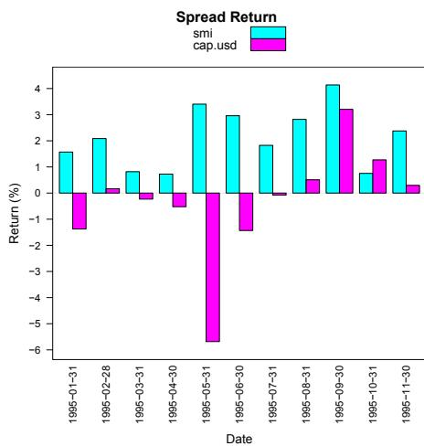

Figure 1: Monthly return spreads.

The top region in this plot shows the cumulative return of each signal on the same return scale, and displays the total return and worst drawdown of the entire backtest period. The bottom region shows the cumulative return of the individual quantiles over time. We can see that `smi`’s top quantile performed best and lowest quantile performed worst. In contrast, `cap.usd`’s lowest quantile was its best performing.

Though it is clear from the summary above that `smi` generated about 5 times as much turnover as `cap.usd`, a plot is available to show the month-by-month turnover of each signal, see Figure 3. This chart shows that the turnover of `smi` was consistently around 50% with lower turnover in September and October, while the turnover of `cap.usd` was consistently around 10%.

```
> plot(bt.save, type = "cumreturn.split")
```

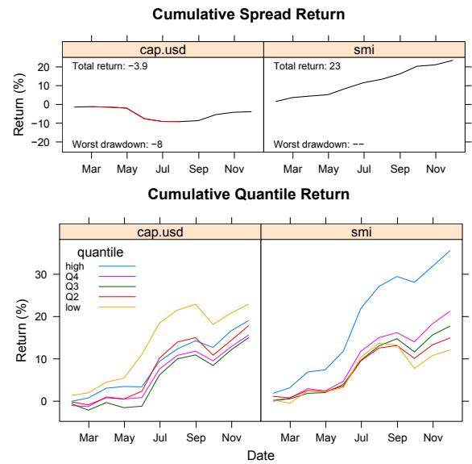

Figure 2: Cumulative spread and quantile returns.

```
> plot(bt, type = "turnover")
```

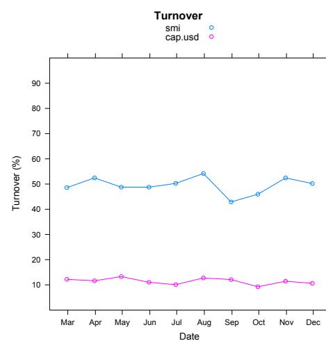

Figure 3: Monthly turnover.

### Using `by.var`

In another type of backtest we can look at quantile spread returns *by* another variable. Specifying `by.var` breaks up quantile returns into categories defined by the levels of the `by.var` column in the input data frame. Consider a backtest of `smi` by sector:

```
> bt <- backtest(starmine, in.var = "smi",
+   ret.var = "fwd.ret.1m",
+   by.var = "sector")

> summary(bt)
```

Backtest conducted with:

```
1 in.var: smi;
1 ret.var: fwd.ret.1m;
and by.var: sector.
```

|  | low | 2 | 3 | 4 | high | spread |
| --- | --- | --- | --- | --- | --- | --- |
| Durbl | 0.0063 | 0.007 | 0.009 | 0.007 | 0.01 | 0.004 |
| Enrgy | 0.0152 | 0.014 | 0.017 | 0.019 | 0.04 | 0.024 |
| HiTec | 0.0237 | 0.016 | 0.026 | 0.029 | 0.05 | 0.024 |
| Hlth | 0.0395 | 0.036 | 0.021 | 0.038 | 0.05 | 0.006 |
| Manuf | 0.0005 | 0.005 | 0.014 | 0.009 | 0.02 | 0.022 |
| Money | 0.0190 | 0.024 | 0.021 | 0.026 | 0.04 | 0.017 |
| NoDur | 0.0036 | 0.010 | 0.010 | 0.019 | 0.03 | 0.025 |
| Other | 0.0045 | 0.006 | 0.015 | 0.017 | 0.02 | 0.017 |
| Shops | 0.0020 | 0.004 | 0.005 | 0.017 | 0.03 | 0.026 |
| Telcm | 0.0277 | 0.014 | 0.022 | 0.023 | 0.03 | 0.005 |
| Utils | 0.0128 | 0.021 | 0.013 | 0.016 | 0.02 | 0.007 |

This backtest categorises observations by the quantiles of *smi* and the levels of *sector*. The highest spread return of 2.6% occurs in *Shops*. Since *smi* quantiles were computed before the observations were split into groups by *sector*, however, we can not be sure how much confidence to place in this result. There could be very few observations in this sector or one of the top and bottom quantiles could have a disproportionate number of observations, thereby making the return calculation suspect. *counts* provides a simple check.

```
> counts(bt)
```

| $smi | low | 2 | 3 | 4 | high |
| --- | --- | --- | --- | --- | --- |
| Durbl | 348 | 349 | 261 | 231 | 223 |
| Enrgy | 246 | 250 | 158 | 130 | 64 |
| HiTec | 647 | 660 | 824 | 1004 | 1432 |
| Hlth | 380 | 377 | 410 | 464 | 424 |
| Manuf | 1246 | 1265 | 1279 | 1395 | 1576 |
| Money | 959 | 1265 | 1244 | 1095 | 875 |
| NoDur | 615 | 563 | 528 | 441 | 371 |
| Other | 1034 | 940 | 784 | 760 | 710 |
| Shops | 870 | 714 | 710 | 697 | 548 |
| Telcm | 186 | 177 | 140 | 129 | 95 |
| Utils | 152 | 245 | 252 | 198 | 130 |

While there seems to be an adequate number of observations in *Shops*, it is important to note that there are approximately 60% more observations contributing to the mean return of the lowest quantile than to the mean return of the highest quantile, 870 versus 548. Overall, we should be more confident in results for *Manuf* and *Money* due to their larger sample sizes. We might want to examine the result for *HiTec* more closely, however, since there are more than twice the number of observations in the highest quantile than the lowest.

*by.var* can also be numeric, as in this backtest using *cap.usd*:

```
> bt <- backtest(starmine,
+   in.var = "smi", ret.var = "fwd.ret.1m",
+   by.var = "cap.usd",
+   buckets = c(5, 10))
```

```
> summary(bt)
```

Backtest conducted with:

```
1 in.var: smi;
1 ret.var: fwd.ret.1m;
and by.var: cap.usd.
```

|  | low | 2 | 3 | 4 | high | spread |
| --- | --- | --- | --- | --- | --- | --- |
| low | 0.0105 | 0.0139 | 0.0236 | 0.028 | 0.038 | 0.028 |
| 2 | 0.0078 | 0.0093 | 0.0216 | 0.025 | 0.046 | 0.038 |
| 3 | 0.0186 | 0.0072 | 0.0167 | 0.031 | 0.034 | 0.016 |
| 4 | 0.0124 | 0.0142 | 0.0139 | 0.013 | 0.038 | 0.026 |
| 5 | 0.0080 | 0.0124 | 0.0087 | 0.010 | 0.025 | 0.017 |
| 6 | 0.0126 | 0.0121 | 0.0191 | 0.021 | 0.026 | 0.013 |
| 7 | 0.0080 | 0.0070 | 0.0160 | 0.019 | 0.034 | 0.026 |
| 8 | 0.0050 | 0.0181 | 0.0101 | 0.014 | 0.027 | 0.022 |
| 9 | 0.0104 | 0.0153 | 0.0167 | 0.014 | 0.028 | 0.018 |
| high | 0.0156 | 0.0207 | 0.0133 | 0.023 | 0.026 | 0.011 |

Since *cap.usd* is numeric, the observations are now split by two sets of quantiles. Those listed across the top are, as before, the input variable quantiles of *smi*. The row names are the quantiles of *cap.usd*. The *buckets* parameter of *backtest* controls the number of quantiles. The higher returns in the lower quantiles of *cap.usd* suggests that *smi* performs better in small cap stocks than in large cap stocks.

## Multiple return horizons

Using *backtest* we can also analyse the performance of a signal relative to multiple return horizons. Below is a backtest that considers one month and six month forward returns together:

```
> bt <- backtest(starmine, in.var = "smi",
+   buckets = 4, ret.var = c("fwd.ret.1m",
+   "fwd.ret.6m"))
```

```
> summary(bt)
```

Backtest conducted with:

```
1 in.var: smi;
2 ret.vars: fwd.ret.1m, fwd.ret.6m;
and no by.var.
```

|  | low | 2 | 3 | high | spread |
| --- | --- | --- | --- | --- | --- |
| fwd.ret.1m | 0.011 | 0.015 | 0.018 | 0.03 | 0.019 |
| fwd.ret.6m | 0.112 | 0.121 | 0.142 | 0.17 | 0.059 |

The performance of *smi* over these two return horizons tells us that the power of the signal degrades after the first month. Using six month forward return, *fwd.ret.6m*, the spread is 6%. This is only 3 times larger than the 2% spread return in the first month despite covering a period which is 6 times longer. In other words, the model produces 2% spread returns in the first month but only 4% in the 5 months which follow.

## Conclusion

The **backtest** package provides a simple collection of tools for performing portfolio-based tests of financial conjectures. A much more complex package, **portfolioSim**, provides facilities for historical portfolio performance analysis using more realistic assumptions. Built on the framework of the **portfolio**<sup>2</sup> package, **portfolioSim** tackles the issues of risk exposures and liquidity constraints, as well as arbitrary portfolio construction and trading rules. Above all, the flexibility of R itself allows users to extend and modify these packages to suit their own needs. Before reaching that level of complexity, however, **backtest** provides a good starting point for testing a new conjecture.

## References

- J. Enos and D. Kane. Analysing equity portfolios in R. *R News*, 6(2):13–19, MAY 2006. URL http://CRAN.R-project.org/doc/Rnews.

Kyle Campbell, Jeff Enos, Daniel Gerlanc and David Kane  
Kane Capital Management  
Cambridge, Massachusetts, USA

Kyle.W.Campbell@williams.edu, jeff@kanecap.com, dgerlanc@gmail.com and david@kanecap.com

[^1]: See www.starmine.com for details.